# Project Foundations for Data Science: FoodHub Data Analysis

### **Question 7**: Which are the top 5 restaurants in terms of the number of orders received?

```python
# Write the code here
df['restaurant_name'].value_counts().head()
```

```
restaurant_name
Shake Shack                  219
The Meatball Shop            132
Blue Ribbon Sushi            119
Blue Ribbon Fried Chicken     96
Parm                          68
Name: count, dtype: int64
```

#### Observations:

The data shows that Shake Shack is the most popular restaurant among customers, with a total of 219 orders, follwed by The Meatball Shop with 132 orders. Parm, with 68 orders,is at 5th place. Although it has fewer orders compared to the other top restaurants, it still manages to secure a position in the top 5, suggesting that it has a decent customer base.

### **Question 8**: Which is the most popular cuisine on weekends?

```python
# Write the code here
Weekend = df[df['day_of_the_week'] == 'Weekend']
Weekend['cuisine_type'].max()
```

```
'Vietnamese'
```

### **Question 9**: What percentage of the orders cost more than 20 dollars?

```python
# Write the code here
#Print orders greater than 20 USD
Greater_20 = df[df['cost_of_the_order'] > 20]

#Print total number of orders that are > 20 USD
print('Total number of orders that costs more than 20 USD:', Greater_20.shape[0])

#Calculate the percentage of orders > 20 USD in the given data
percent = (Greater_20.shape[0] / df.shape[0]) * 100
print("Percentage of orders cost above 20 USD: ", round(percent, 2), '%', sep = '')
```

```
Total number of orders that costs more than 20 USD: 555
Percentage of orders cost above 20 USD: 29.24%
```

### **Question 10**: What is the mean order delivery time?

```python
# Write the code here
#find the mean delivery time of the given data
Mean = df['delivery_time'].mean()
print('The mean delivery time of the given data: ', round(Mean), 'minutes')
```

```
The mean delivery time of the given data:  24 minutes
```

#### Observations:

The average delivery time is around 24 minutes

### **Question 11:** The company has decided to give 20% discount vouchers to the top 3 most frequent customers. Find the IDs of these customers and the number of orders they placed

```python
# Write the code here
# Find the top 3 customers
df['customer_id'].value_counts().head(3)
```

```
customer_id
52832    13
47440    10
83287     9
Name: count, dtype: int64
```

#### Observations:

Customers with ID numbers 52832, 47440, and 83287 are most frequent, who are supposed to get the 20% discount vouchers.

### **Question 12**: Perform a multivariate analysis to explore relationships between the important variables in the dataset. (It is a good idea to explore relations between numerical variables as well as relations between numerical and categorical variables)

```python
# Write the code here
df['order_id']
```

```
0       1477147
1       1477685
2       1477070
3       1477334
4       1478249
         ...
1893    1476701
1894    1477421
1895    1477819
1896    1477513
1897    1478056
Name: order_id, Length: 1898, dtype: int64
```

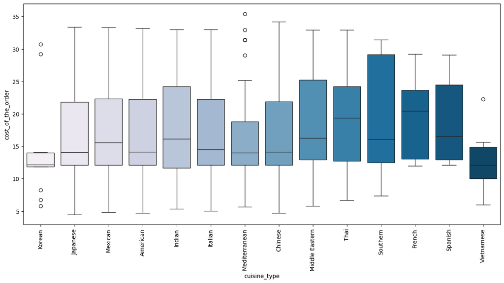

```python
#analysing the relation between cost of order and cuisine type
plt.figure(figsize = (15, 7))
sns.boxplot(x = "cuisine_type", y = "cost_of_the_order", data = df, hue = 'cuisine_type', palette = 'PuBu') #visualize the relationship between cuisine type and cost of order using boxplot
plt.xticks(rotation = 90)
plt.show()
```

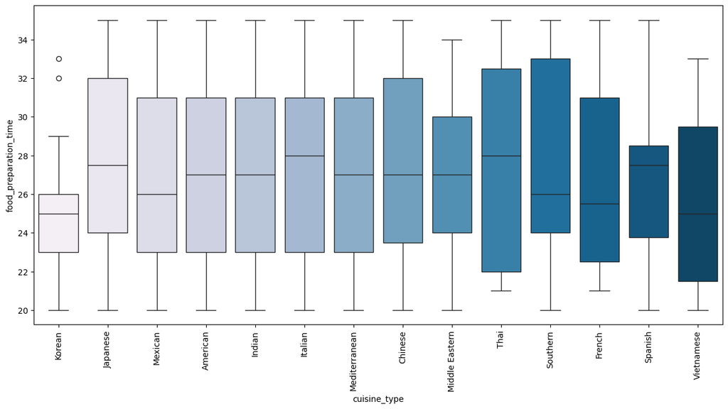

```python
# Analyzing the reltion between Cusine type and food preparation time
plt.figure(figsize = (15, 7))
sns.boxplot(data = df, x = 'cuisine_type', y = 'food_preparation_time', hue = 'cuisine_type', palette= 'PuBu') # visualize the relation between food preparation time and cuisine type using boxplot
plt.xticks(rotation = 90)
plt.show()
```

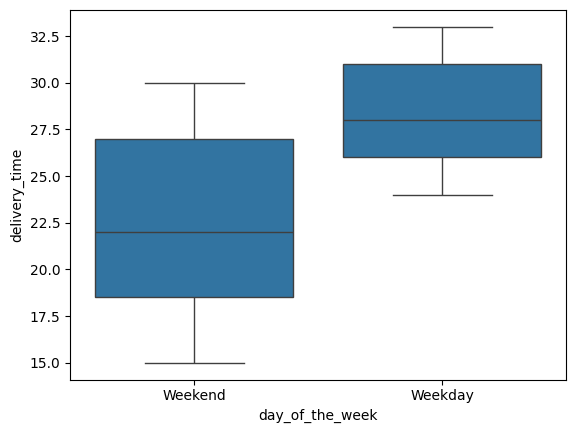

```python
#Analyze the relation between the day of the week and delivery time
sns.boxplot(data = df, x = "day_of_the_week", y = "delivery_time") #visualize the relation using boxplot
plt.show()
```

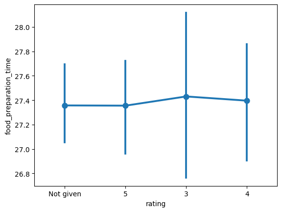

```python
#Analyze the relationship between the food preparation time and food rating
sns.pointplot(data = df, x = 'rating', y = 'food_preparation_time') # visualize the relationship between 'rating' and 'food_preparation_time' columns using boxplot
plt.show()
```

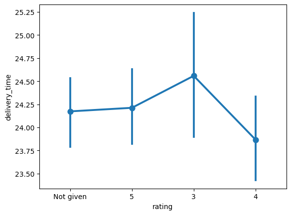

```python
#Analyze the relationship between the delivery time and food rating
sns.pointplot(data = df, x = 'rating', y = 'delivery_time') # visualize the relationship between 'rating' and 'delivery_time' columns using point plot
plt.show()
```

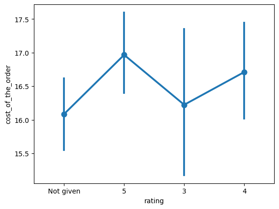

```python
#Analyze the relation between cost of order and food rating
sns.pointplot(data = df, x = 'rating', y = 'cost_of_the_order') # visualize the relation between 'rating' and 'cost_of_the_order' using point plot
plt.show()
```

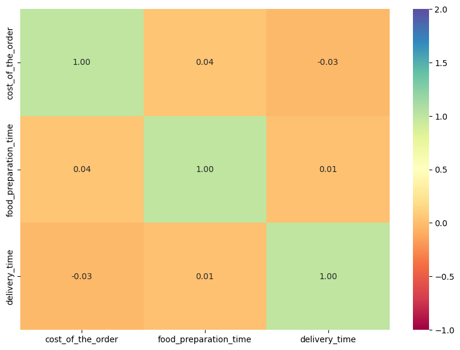

```python
# Plot the heatmap for the given data
# columns for the heatmap
col_list = ['cost_of_the_order', 'food_preparation_time', 'delivery_time']
plt.figure(figsize=(10, 7))
sns.heatmap(df[col_list].corr(), annot = True, vmin = -1, vmax = 2, fmt = ".2f", cmap = "Spectral") #Generate the heatmap to show the correlation matrix of the given columns
plt.show()
```

```python
df.groupby(['restaurant_name'])['cost_of_the_order'].sum().sort_values(ascending = False).head(14)
```

```
restaurant_name
Shake Shack                      3579.53
The Meatball Shop                2145.21
Blue Ribbon Sushi                1903.95
Blue Ribbon Fried Chicken        1662.29
Parm                             1112.76
RedFarm Broadway                  965.13
RedFarm Hudson                    921.21
TAO                               834.50
Han Dynasty                       755.29
Blue Ribbon Sushi Bar & Grill     666.62
Rubirosa                          660.45
Sushi of Gari 46                  640.87
Nobu Next Door                    623.67
Five Guys Burgers and Fries       506.47
Name: cost_of_the_order, dtype: float64
```

```python
# Write the code here
# Filter the rated restaurants
df_rated = df[df['rating'] != 'Not given'].copy()

# Convert rating to integer
df_rated['rating'] = df_rated['rating'].astype('int')

# Create a dataframe that contains the restaurant names with their rating counts
df_rating_count = df_rated.groupby(['restaurant_name'])['rating'].count().sort_values(ascending = False).reset_index()
df_rating_count.head()
```

|  | restaurant_name | rating |
| --- | --- | --- |
| 0 | Shake Shack | 133 |
| 1 | The Meatball Shop | 84 |
| 2 | Blue Ribbon Sushi | 73 |
| 3 | Blue Ribbon Fried Chicken | 64 |
| 4 | RedFarm Broadway | 41 |

### **Question 14:** The company charges the restaurant 25% on the orders having cost greater than 20 dollars and 15% on the orders having cost greater than 5 dollars. Find the net revenue generated by the company across all orders

```python
# Write the code here
#Determine the revenue
def revenue(x):
    if x > 20:
        return x*0.25
    elif x > 5:
        return x*0.15
    else:
        return x*0

df['Revenue'] = df['cost_of_the_order'].apply(revenue)
df.head()
```

|  | order_id | customer_id | restaurant_name | cuisine_type | cost_of_the_order | day_of_the_week | rating | food_preparation_time | delivery_time | Revenue |
| --- | --- | --- | --- | --- | --- | --- | --- | --- | --- | --- |
| 0 | 1477147 | 337525 | Hangawi | Korean | 30.75 | Weekend | Not given | 25 | 20 | 7.6875 |
| 1 | 1477685 | 358141 | Blue Ribbon Sushi Izakaya | Japanese | 12.08 | Weekend | Not given | 25 | 23 | 1.8120 |
| 2 | 1477070 | 66393 | Cafe Habana | Mexican | 12.23 | Weekday | 5 | 23 | 28 | 1.8345 |
| 3 | 1477334 | 106968 | Blue Ribbon Fried Chicken | American | 29.20 | Weekend | 3 | 25 | 15 | 7.3000 |
| 4 | 1478249 | 76942 | Dirty Bird to Go | American | 11.59 | Weekday | 4 | 25 | 24 | 1.7385 |

```python
#Total revenue generated
total_rev = df['Revenue'].sum() # generate the total revenue
print('The revenue generated is around', round(total_rev, 1), 'USD')
```

```
The revenue generated is around 6166.3 USD
```

### **Question 15:** The company wants to analyze the total time required to deliver the food. What percentage of orders take more than 60 minutes to get delivered from the time the order is placed? (The food has to be prepared and then delivered)

```python
# Write the code here
# Calculate the total time and add the new column to the present data
df['total_time'] = df['food_preparation_time'] + df['delivery_time']

# Obtain the number of total time delivery greater than 60
orders_above_60_min = df[df['total_time'] > 60].shape[0]

# Calculate the percentage of orders that take more than 60 minutes to deliver
percentage = round((orders_above_60_min / df.shape[0]) * 100, 2)

print(percentage ,"%", " of oders take more than 60 minutes to get delivered from time the order is placed.", sep='')
```

```
10.54% of oders take more than 60 minutes to get delivered from time the order is placed.
```

#### Observations:

10.5% of orders take more than 60 minutes to be delivered from the time the order is placed. This indicates that a small yet significant portion of orders experience extended delivery times.

### **Question 16:** The company wants to analyze the delivery time of the orders on weekdays and weekends. How does the mean delivery time vary during weekdays and weekends?

```python
# Write the code here
#The mean delivery time on weekdays
print('The mean delivery time on weekdays is around', round(df[df['day_of_the_week'] == 'Weekday']['delivery_time'].mean()),'minutes')

#The mean delivery time on weekends
print('The mean delivery time on weekends is around', round(df[df['day_of_the_week'] == 'Weekend']['delivery_time'].mean()),'minutes')
```

```
The mean delivery time on weekdays is around 28 minutes
The mean delivery time on weekends is around 22 minutes
```

#### Observations:

The shorter mean delivery time on weekends (22 minutes) compared to weekdays (28 minutes) suggests that deliveries are more efficient during weekends. This could be due to several factors, such as: Less traffic, different operational dynamics, and higher staffing levels to handle weekend demand

### Conclusion and Recommendations

### **Question 17:** What are your conclusions from the analysis? What recommendations would you like to share to help improve the business? (You can use cuisine type and feedback ratings to drive your business recommendations)

### Conclusions:

- Order Distribution:
1. Shake Shack is the most popular restaurant with 219 orders, followed by The Meatball Shop (132 orders) and Blue Ribbon Sushi (119 orders).
2. There's a significant gap between the top performer and others, indicating strong customer preferences.
- Ratings: A large number of orders (736) are not rated, which could impact the ability to gather comprehensive customer feedback.
- Delivery Times:
1. The average food preparation time is about 27 minutes, with delivery times averaging around 24 minutes.
2. Some orders take more than 60 minutes for total delivery time (preparation + delivery).
- Cost and Revenue:
1. The average order cost is around $16.50, with a range from $4.47 to $35.41.
2. The company generates revenue based on a percentage of the order cost, with higher percentages for more expensive orders.

### Recommendations:

- Improve Rating Collection:
1. Implement a system to encourage customers to rate their orders, such as offering small discounts on future orders for leaving feedback.
2. Simplify the rating process to make it quick and easy for customers.
- Optimize Delivery Times:
1. Focus on reducing the number of orders that take more than 60 minutes for total delivery time.
2. Analyze factors contributing to longer delivery times and address them (e.g., restaurant location, traffic patterns, staffing issues).
- Partner with Popular Restaurants:
1. Strengthen partnerships with top-performing restaurants like Shake Shack to potentially negotiate better terms or exclusive deals.
2. Feature these popular restaurants more prominently in the app to drive more orders.
- Cuisine Variety:
1. Analyze the performance of different cuisine types and ensure a good mix of popular cuisines is available.
2. Consider promoting less popular but high-quality cuisines to diversify options and potentially increase order volume.
- Pricing Strategy:
1. Review the current pricing structure and consider adjusting the commission rates to optimize revenue while remaining competitive.
2. Implement targeted promotions for mid-range orders to encourage customers to increase their order value.
- Customer Segmentation:
1. Analyze customer ordering patterns and create targeted marketing campaigns for different customer segments (e.g., frequent orderers, high-value customers, weekend vs. weekday orderers).
- Quality Control:
1. Use the ratings data to identify consistently high-performing restaurants and cuisines, and feature them more prominently.
2. Work with lower-rated restaurants to improve their service and food quality.
- Operational Efficiency:
1. Analyze preparation and delivery times by restaurant and cuisine type to identify bottlenecks and implement best practices across the platform.
- Technology Enhancements:
1. Invest in improving the app's user interface and features based on customer feedback and industry trends.
2. Consider implementing AI-driven recommendations to personalize the user experience and potentially increase order frequency and value.